# Developing Data Products: Week 4 Project

Steve Johnson

April 28, 2018

# Iris Dataset

My Shiny app uses the popular iris dataset which consists of flower measurements from Ronald Fisher’s 1936 paper “The use of multiple measurements in taxonomic problems.” This dataset consists of length and width measurements of sepals and petals from 3 species of iris.

```
##   Sepal.Length Sepal.Width Petal.Length Petal.Width Species
## 1          5.1         3.5          1.4         0.2  setosa
## 2          4.9         3.0          1.4         0.2  setosa
## 3          4.7         3.2          1.3         0.2  setosa
```

# Dynamic Linear Model Modification and Fitting

This Shiny app builds a linear model with Sepal length as the dependent variable. The user selects model factors from the dataset to include, whether factor interactions should be considered, and then clicks a “Submit” button.

This initiates the server calculation wherein the linear model is formulated and fitted. This model’s predicted Sepal Lengths are generated, based on the subset of input data, along with 95% confidence intervals. This is then used to generate a plot.

The R files server.R and ui.R are in a github repo at https://github.com/mendl767/DataProdWeek4

# Model Plotting

A plot is generated of the observed versus predicted sepal lengths. The 95% confidence interval for each predicted value is displayed as a gray band.

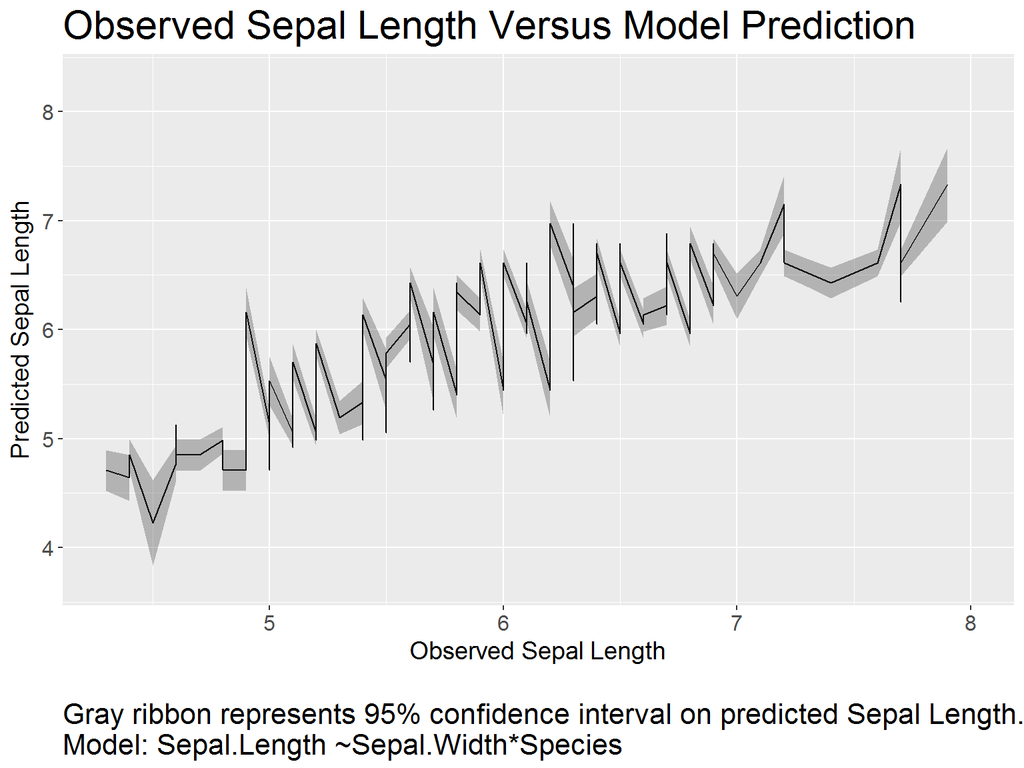

# Final Notes

- If the user does not select at least 1 independent variable, this is caught by the server.R code and “Please select at least 1 model factor” is displayed instead of the plot.
- The model formula displayed in the caption below the plot is dynamic and responds to the user selections.
- Thanks and I hope you enjoyed my app.